# Ejemplo Diagnóstico

María Sánchez Paniagua

2024-04-30

# 1 Ejemplo 1

## 1.1 Introduction

Cargamos el paquete faraway y accedemos al conjunto de datos savings desde dicho paquete.

```r
library(faraway)
data(savings)
savings
```

```
##                   sr pop15 pop75     dpi  ddpi
## Australia      11.43 29.35  2.87 2329.68  2.87
## Austria        12.07 23.32  4.41 1507.99  3.93
## Belgium        13.17 23.80  4.43 2108.47  3.82
## Bolivia         5.75 41.89  1.67  189.13  0.22
## Brazil         12.88 42.19  0.83  728.47  4.56
## Canada          8.79 31.72  2.85 2982.88  2.43
## Chile           0.60 39.74  1.34  662.86  2.67
## China          11.90 44.75  0.67  289.52  6.51
## Colombia        4.98 46.64  1.06  276.65  3.08
## Costa Rica     10.78 47.64  1.14  471.24  2.80
## Denmark        16.85 24.42  3.93 2496.53  3.99
## Ecuador         3.59 46.31  1.19  287.77  2.19
## Finland        11.24 27.84  2.37 1681.25  4.32
## France         12.64 25.06  4.70 2213.82  4.52
## Germany        12.55 23.31  3.35 2457.12  3.44
## Greece         10.67 25.62  3.10  870.85  6.28
## Guatamala       3.01 46.05  0.87  289.71  1.48
## Honduras        7.70 47.32  0.58  232.44  3.19
## Iceland         1.27 34.03  3.08 1900.10  1.12
## India           9.00 41.31  0.96   88.94  1.54
## Ireland        11.34 31.16  4.19 1139.95  2.99
## Italy          14.28 24.52  3.48 1390.00  3.54
## Japan          21.10 27.01  1.91 1257.28  8.21
## Korea           3.98 41.74  0.91  207.68  5.81
## Luxembourg     10.35 21.80  3.73 2449.39  1.57
## Malta          15.48 32.54  2.47  601.05  8.12
## Norway         10.25 25.95  3.67 2231.03  3.62
## Netherlands    14.65 24.71  3.25 1740.70  7.66
## New Zealand    10.67 32.61  3.17 1487.52  1.76
## Nicaragua       7.30 45.04  1.21  325.54  2.48
## Panama          4.44 43.56  1.20  568.56  3.61
## Paraguay        2.02 41.18  1.05  220.56  1.03
## Peru           12.70 44.19  1.28  400.06  0.67
## Philippines    12.78 46.26  1.12  152.01  2.00
## Portugal       12.49 28.96  2.85  579.51  7.48
## South Africa   11.14 31.94  2.28  651.11  2.19
## South Rhodesia 13.30 31.92  1.52  250.96  2.00
## Spain          11.77 27.74  2.87  768.79  4.35
## Sweden          6.86 21.44  4.54 3299.49  3.01
## Switzerland    14.13 23.49  3.73 2630.96  2.70
## Turkey          5.13 43.42  1.08  389.66  2.96
## Tunisia         2.81 46.12  1.21  249.87  1.13
## United Kingdom  7.81 23.27  4.46 1813.93  2.01
## United States   7.56 29.81  3.43 4001.89  2.45
## Venezuela       9.22 46.40  0.90  813.39  0.53
## Zambia         18.56 45.25  0.56  138.33  5.14
## Jamaica         7.72 41.12  1.73  380.47 10.23
## Uruguay         9.24 28.13  2.72  766.54  1.88
## Libya           8.89 43.69  2.07  123.58 16.71
## Malaysia        4.71 47.20  0.66  242.69  5.08
```

Modelo de regresión lineal M1

```r
M1 <- lm(sr ~ pop15 + pop75 + dpi + ddpi, data=savings)
(M1_sum <- summary(M1))    # summary of estimated model
```

```
##
## Call:
## lm(formula = sr ~ pop15 + pop75 + dpi + ddpi, data = savings)
##
## Residuals:
##     Min      1Q  Median      3Q     Max
## -8.2422 -2.6857 -0.2488  2.4280  9.7509
##
## Coefficients:
##               Estimate Std. Error t value Pr(>|t|)
## (Intercept) 28.5660865  7.3545161   3.884 0.000334 ***
## pop15       -0.4611931  0.1446422  -3.189 0.002603 **
## pop75       -1.6914977  1.0835989  -1.561 0.125530
## dpi         -0.0003369  0.0009311  -0.362 0.719173
## ddpi         0.4096949  0.1961971   2.088 0.042471 *
## ---
## Signif. codes:  0 '***' 0.001 '**' 0.01 '*' 0.05 '.' 0.1 ' ' 1
##
## Residual standard error: 3.803 on 45 degrees of freedom
## Multiple R-squared:  0.3385, Adjusted R-squared:  0.2797
## F-statistic: 5.756 on 4 and 45 DF,  p-value: 0.0007904
```

Los valores ajustados $\hat{Y}_i$ y los residuos $e_i$ se pueden obtener de la siguiente manera:

```r
fitted(M1)                    # Valores Y_i predichos
```

```
##      Australia        Austria        Belgium        Bolivia         Brazil
##      10.566420      11.453614      10.951042       6.448319       9.327191
##         Canada          Chile          China       Colombia     Costa Rica
##       9.106892       8.842231       9.363964       6.431707       5.654922
##        Denmark        Ecuador        Finland         France        Germany
##      11.449761       5.995631      12.921086      10.164528      12.730699
##         Greece      Guatamala       Honduras        Iceland          India
##      13.786168       6.365284       6.989976       7.480582       8.491326
##        Ireland          Italy          Japan          Korea     Luxembourg
##       7.948869      12.353245      15.818514      10.086981      12.020807
##          Malta         Norway    Netherlands    New Zealand      Nicaragua
##      12.505090      11.121785      14.224454       8.384445       6.653603
##         Panama       Paraguay           Peru    Philippines       Portugal
##       7.734166       8.145759       6.160559       6.104992      13.258445
##   South Africa South Rhodesia          Spain         Sweden    Switzerland
##      10.656834      12.008566      12.441156      11.120283      11.643174
##         Turkey        Tunisia United Kingdom  United States      Venezuela
##       7.795682       5.627920      10.502413       8.671590       5.587482
##         Zambia        Jamaica        Uruguay          Libya       Malaysia
##       8.809086      10.738531      11.503827      11.719526       7.680869
```

```r
residuals(M1)                 # Residuos e_i
```

```
##      Australia        Austria        Belgium        Bolivia         Brazil
##      0.8635798      0.6163860      2.2189579     -0.6983191      3.5528094
##         Canada          Chile          China       Colombia     Costa Rica
##     -0.3168924     -8.2422307      2.5360361     -1.4517071      5.1250782
##        Denmark        Ecuador        Finland         France        Germany
##      5.4002388     -2.4056313     -1.6810857      2.4754718     -0.1806993
##         Greece      Guatamala       Honduras        Iceland          India
##     -3.1161685     -3.3552838      0.7100245     -6.2105820      0.5086740
##        Ireland          Italy          Japan          Korea     Luxembourg
##      3.3911306      1.9267549      5.2814855     -6.1069814     -1.6708066
##          Malta         Norway    Netherlands    New Zealand      Nicaragua
##      2.9749098     -0.8717854      0.4255455      2.2855548      0.6463966
##         Panama       Paraguay           Peru    Philippines       Portugal
##     -3.2941656     -6.1257589      6.5394410      6.6750084     -0.7684447
##   South Africa South Rhodesia          Spain         Sweden    Switzerland
##      0.4831656      1.2914342     -0.6711565     -4.2602834      2.4868259
##         Turkey        Tunisia United Kingdom  United States      Venezuela
##     -2.6656824     -2.8179200     -2.6924128     -1.1115901      3.6325177
##         Zambia        Jamaica        Uruguay          Libya       Malaysia
##      9.7509138     -3.0185314     -2.2638273     -2.8295257     -2.9708690
```

```r
which.max(abs(residuals(M1))) # Residual absoluto más grande |e_i|?
```

```
## Zambia
##     46
```

Vista gráfica general utilizando la función `plot()` en un objeto `lm`.

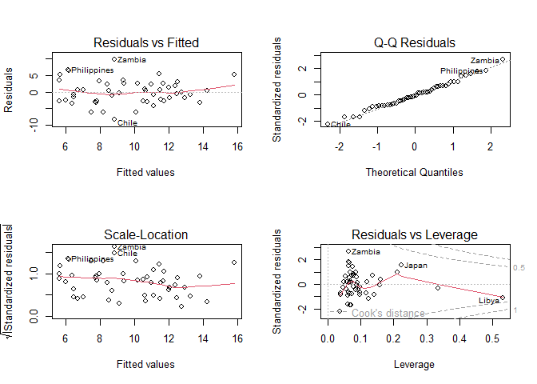

```r
oldpar <- par(mfrow=c(2,2))
plot(M1)
```

```r
par(oldpar)
```

El mismo gráfico con el paquete `gglm`.

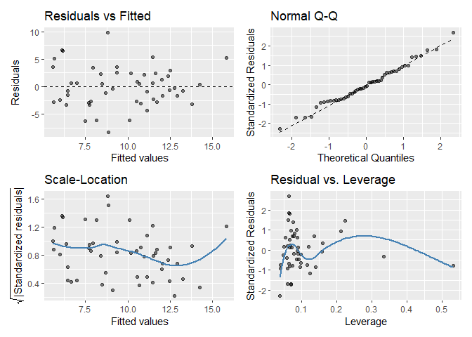

```r
library(gglm)
gglm(M1)
```

## 1.2 Checking model assumptions

### 1.2.1 Varianza constante

**Plot de residuos: $\hat{Y}_i$ contra $e_i$**

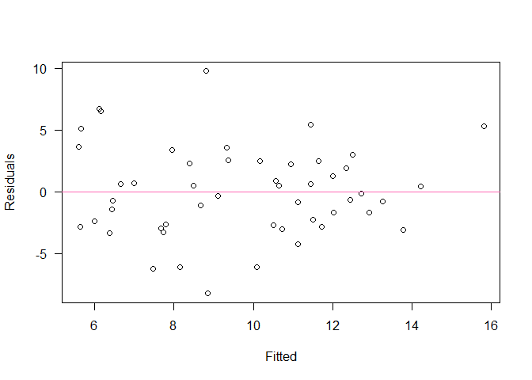

```r
par(las=1)               # labels horizontales
plot(fitted(M1), residuals(M1), xlab="Fitted", ylab="Residuals")
abline(h=0, col="hotpink")   # Dibujar linea horizontal en y=0
```

Plot de diagnóstico para `lm()`.

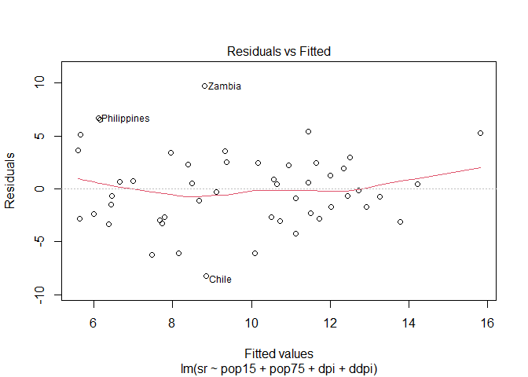

```r
plot(M1, which=1)
```

Lo mismo con `gglm`

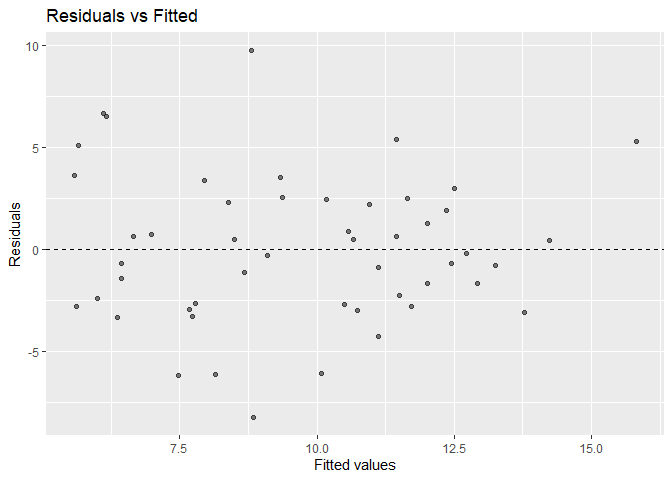

```r
ggplot2::ggplot(data = M1) + stat_fitted_resid()
```

**Gráfico de residuos absolutos: $\hat{Y}_i$ contra $|e_i|$**

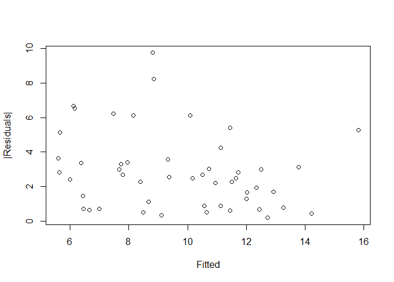

```r
plot(fitted(M1), abs(residuals(M1)), xlab="Fitted", ylab="|Residuals|")
```

**Gráfico de residuos absolutos: $\hat{Y}_i$ contra sqrt(standardized $|e_i|$))**

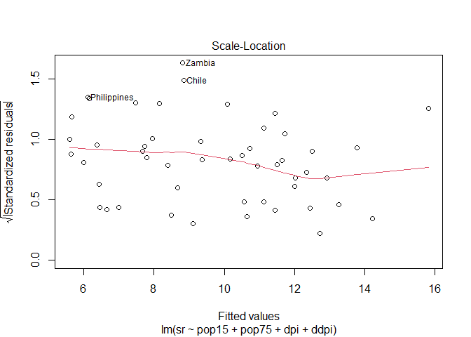

```r
plot(M1, which=3) # El tercero es el que buscamos
```

Con el paquete `gglm`

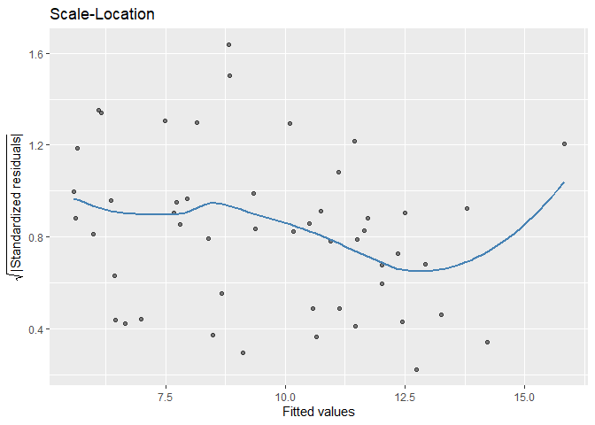

```r
ggplot2::ggplot(data = M1) + stat_scale_location()
```

**Prueba rápida y sencilla (Faraway)**

```r
summary(lm(abs(residuals(M1)) ~ fitted(M1)))
```

```
##
## Call:
## lm(formula = abs(residuals(M1)) ~ fitted(M1))
##
## Residuals:
##     Min      1Q  Median      3Q     Max
## -2.8395 -1.6078 -0.3493  0.6625  6.7036
##
## Coefficients:
##             Estimate Std. Error t value Pr(>|t|)
## (Intercept)   4.8398     1.1865   4.079  0.00017 ***
## fitted(M1)   -0.2035     0.1185  -1.717  0.09250 .
## ---
## Signif. codes:  0 '***' 0.001 '**' 0.01 '*' 0.05 '.' 0.1 ' ' 1
##
## Residual standard error: 2.163 on 48 degrees of freedom
## Multiple R-squared:  0.05784,    Adjusted R-squared:  0.03821
## F-statistic: 2.947 on 1 and 48 DF,  p-value: 0.0925
```

El R-cuadrado ajustado es bajo (0.0382), lo que indica que el modelo no explica una gran proporción de la variabilidad en la magnitud absoluta de los residuos. El valor p del estadístico F es 0.0925, lo que sugiere que el modelo no es significativo a un nivel de significancia típico (como 0.05). En otras palabras, no hay suficiente evidencia para rechazar la hipótesis nula de que los coeficientes del modelo son cero.

**Interpretación de gráficos de residuos**

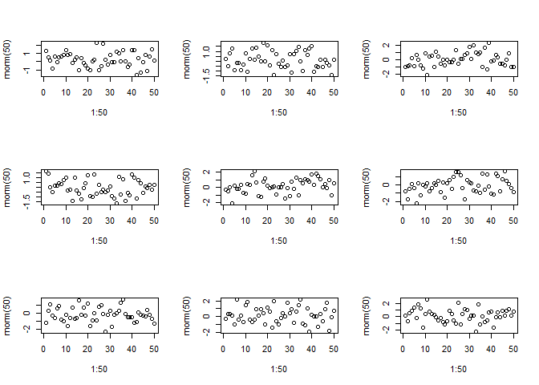

```r
par(mfrow=c(3,3))
for(i in 1:9) plot(1:50,rnorm(50))              # constant variance
```

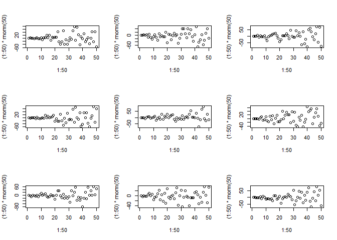

```r
for(i in 1:9) plot(1:50,(1:50)*rnorm(50))       # strong heterogeneity
```

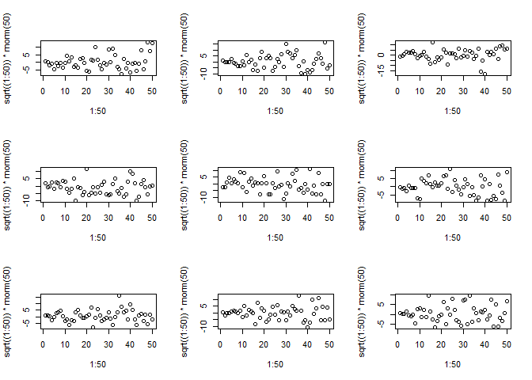

```r
for(i in 1:9) plot(1:50,sqrt((1:50))*rnorm(50)) # mild heterogeneity
```

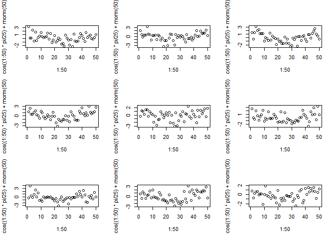

```r
for(i in 1:9) plot(1:50,cos((1:50)*pi/25)+rnorm(50)) # non-linearity
```

### 1.2.2 Normalidad

**Q-Q plots**

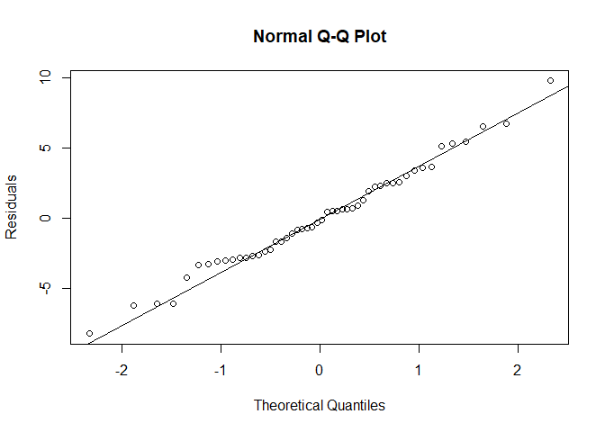

```r
par(mfrow=c(1,1))                       # reset plotting device
qqnorm(residuals(M1), ylab="Residuals") # Q-Q plot
qqline(residuals(M1))                   # line through Q1 and Q3
```

Con el paquete `gglm`

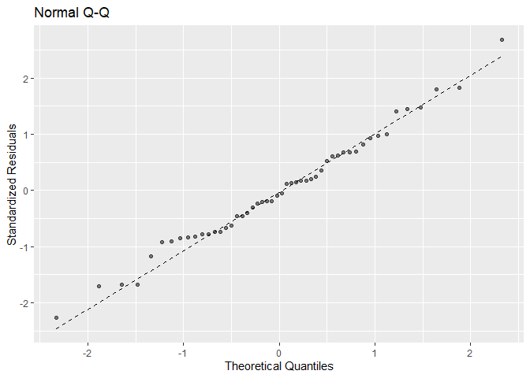

```r
ggplot2::ggplot(data = M1) + stat_normal_qq()
```

**Interpretación de los QQplots**

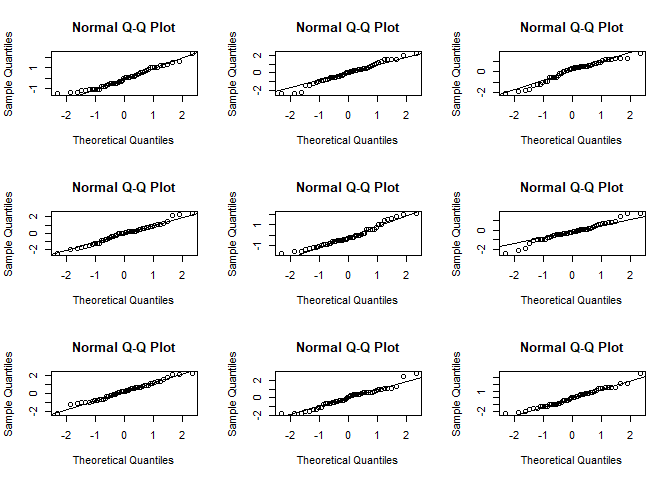

```r
par(mfrow=c(3,3))
# standard normal distribution (symmetric)
for(i in 1:9) {x = rnorm(50); qqnorm(x); qqline(x)}
```

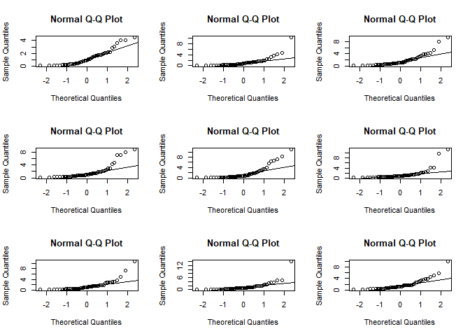

```r
# lognormal distribution (long right tail, skew to right)
for(i in 1:9) {x = rlnorm(50); qqnorm(x); qqline(x)}
```

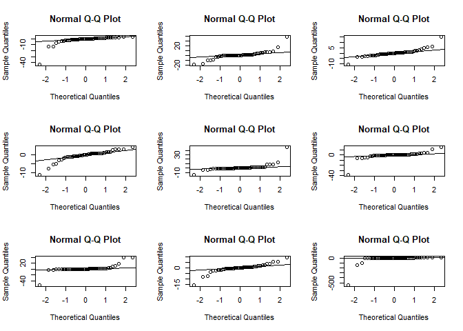

```r
# Student t-distribution with one df (heavy tails, platykurtic)
for(i in 1:9) {x = rt(50,1); qqnorm(x); qqline(x)}
```

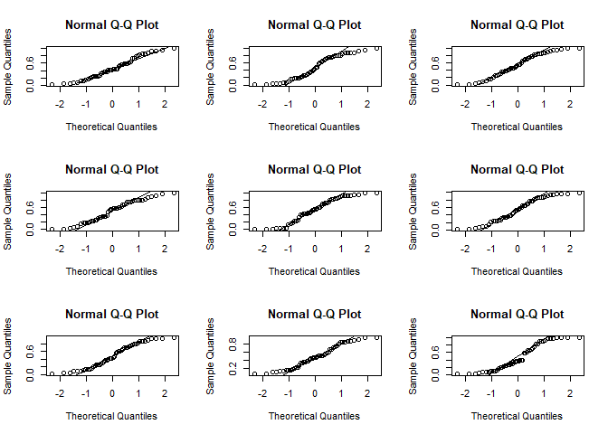

```r
# uniform (0,1) distribution (short tails, leptokurtic)
for(i in 1:9) {x = runif(50); qqnorm(x); qqline(x)}
```

**Histogramas y boxplots**

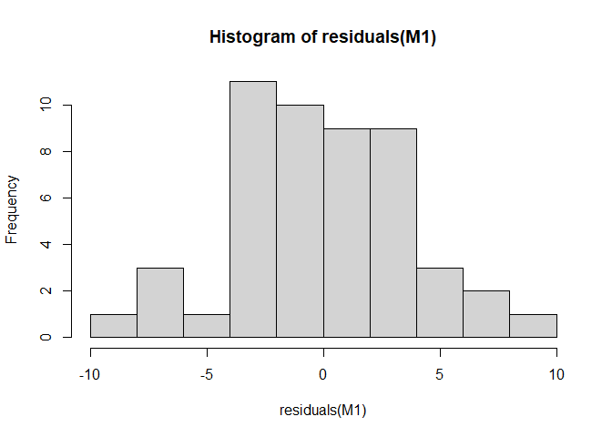

```r
par(mfrow=c(1,1))
hist(residuals(M1))
```

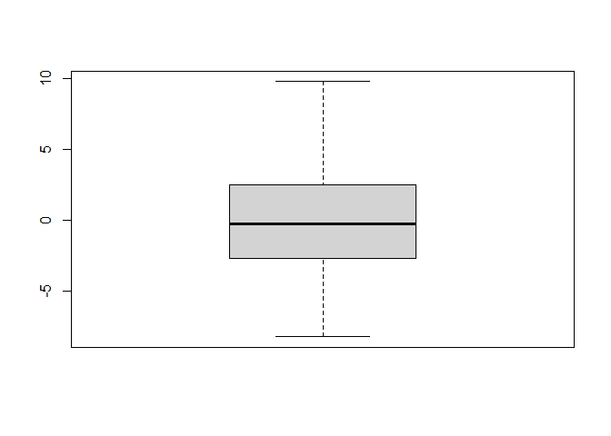

```r
boxplot(residuals(M1))
```

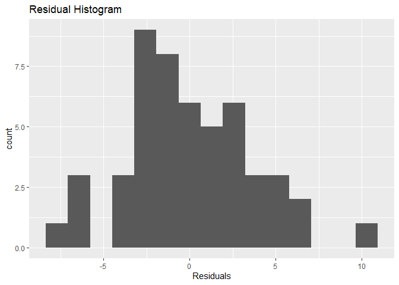

```r
ggplot2::ggplot(data = M1) + stat_resid_hist(bins=15)
```

** Test de normalidad Shapiro-Wilk **

```r
shapiro.test(residuals(M1))
```

```
##
##  Shapiro-Wilk normality test
##
## data:  residuals(M1)
## W = 0.98698, p-value = 0.8524
```

No hay suficiente evidencia para rechazar la hipótesis nula de que los residuos provienen de una distribución normal.

### 1.2.3 Independent errors

The data set `airquality` from the `datasets` package serves as a more appropriate illustration here than the `savings` data.

```r
attach(airquality)
str(airquality)
```

```
## 'data.frame':    153 obs. of  6 variables:
##  $ Ozone  : int  41 36 12 18 NA 28 23 19 8 NA ...
##  $ Solar.R: int  190 118 149 313 NA NA 299 99 19 194 ...
##  $ Wind   : num  7.4 8 12.6 11.5 14.3 14.9 8.6 13.8 20.1 8.6 ...
##  $ Temp   : int  67 72 74 62 56 66 65 59 61 69 ...
##  $ Month  : int  5 5 5 5 5 5 5 5 5 5 ...
##  $ Day    : int  1 2 3 4 5 6 7 8 9 10 ...
```

**Scatter plots**

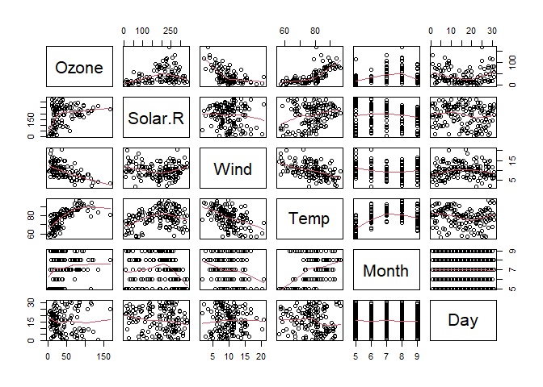

```r
pairs(airquality, panel=panel.smooth)
```

Inspection of correlations for linear relationships (listwise deletion of missing cases).

```r
round(cor(airquality, use="complete.obs"), digits=2)
```

```
##         Ozone Solar.R  Wind  Temp Month   Day
## Ozone    1.00    0.35 -0.61  0.70  0.14 -0.01
## Solar.R  0.35    1.00 -0.13  0.29 -0.07 -0.06
## Wind    -0.61   -0.13  1.00 -0.50 -0.19  0.05
## Temp     0.70    0.29 -0.50  1.00  0.40 -0.10
## Month    0.14   -0.07 -0.19  0.40  1.00 -0.01
## Day     -0.01   -0.06  0.05 -0.10 -0.01  1.00
```

Next a linear regression model `M2` for `Ozone` is fitted to the data, where `Month` and `Day` are not used as linear predictors.

```r
M2 <- lm(Ozone ~ Solar.R + Wind + Temp, data=airquality,
                na.action=na.exclude)
summary(M2)
```

```
##
## Call:
## lm(formula = Ozone ~ Solar.R + Wind + Temp, data = airquality,
##     na.action = na.exclude)
##
## Residuals:
##     Min      1Q  Median      3Q     Max
## -40.485 -14.219  -3.551  10.097  95.619
##
## Coefficients:
##              Estimate Std. Error t value Pr(>|t|)
## (Intercept) -64.34208   23.05472  -2.791  0.00623 **
## Solar.R       0.05982    0.02319   2.580  0.01124 *
## Wind         -3.33359    0.65441  -5.094 1.52e-06 ***
## Temp          1.65209    0.25353   6.516 2.42e-09 ***
## ---
## Signif. codes:  0 '***' 0.001 '**' 0.01 '*' 0.05 '.' 0.1 ' ' 1
##
## Residual standard error: 21.18 on 107 degrees of freedom
##   (42 observations deleted due to missingness)
## Multiple R-squared:  0.6059, Adjusted R-squared:  0.5948
## F-statistic: 54.83 on 3 and 107 DF,  p-value: < 2.2e-16
```

```r
table(complete.cases(airquality))
```

```
##
## FALSE  TRUE
##    42   111
```

We notice that the data frame has missing values. There are 111 complete cases only. The default with respect to missing values for regression analysis in R is to omit any case that contains a missing value. The option `na.action=na.exclude` does not use cases with missing values in the computation but keeps track of which cases are missing in the residual, fitted values and other quantities.

Residual diagnostics show some non-constant variance and non-linearity –see the previous `pairs()` plots. Therefore, a logarithmic transformation of the response variable `Ozone` is made, resulting in model `M2_log`.

**Transformation of the response variable**

```r
M2_log <- lm(log(Ozone) ~ Solar.R + Wind + Temp, airquality, na.action=na.exclude)
summary(M2_log)
```

```
##
## Call:
## lm(formula = log(Ozone) ~ Solar.R + Wind + Temp, data = airquality,
##     na.action = na.exclude)
##
## Residuals:
##      Min       1Q   Median       3Q      Max
## -2.06193 -0.29970 -0.00231  0.30756  1.23578
##
## Coefficients:
##               Estimate Std. Error t value Pr(>|t|)
## (Intercept) -0.2621323  0.5535669  -0.474 0.636798
## Solar.R      0.0025152  0.0005567   4.518 1.62e-05 ***
## Wind        -0.0615625  0.0157130  -3.918 0.000158 ***
## Temp         0.0491711  0.0060875   8.077 1.07e-12 ***
## ---
## Signif. codes:  0 '***' 0.001 '**' 0.01 '*' 0.05 '.' 0.1 ' ' 1
##
## Residual standard error: 0.5086 on 107 degrees of freedom
##   (42 observations deleted due to missingness)
## Multiple R-squared:  0.6644, Adjusted R-squared:  0.655
## F-statistic: 70.62 on 3 and 107 DF,  p-value: < 2.2e-16
```

Notice the improvement of fit of model `M2_log` over that of model `M2`, where `Ozone` was untransformed.

We now check for correlated error terms. Recall that there is a time component in the airquality data.

**Index plot of residuals $e_i$, i.e., a plot of $e_i$ against time**

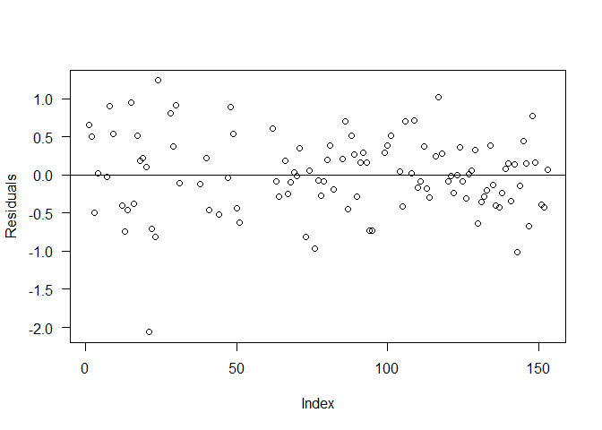

```r
par(las=1, mfrow=c(1,1))
plot(residuals(M2_log), ylab="Residuals")
abline(h=0)
```

If there was serial correlation, we would see either long runs of residuals above or below the line for positive correlation, or greater than normal fluctuations for negative correlation. Unless the effects are strong, they may be difficult to detect. Therefore, it is often better to plot successive residuals.

**Plot of successive residuals $e_i$ against $e_{i+1}$**

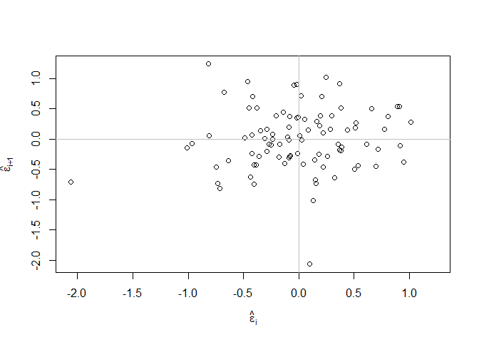

```r
n <- length(residuals(M2_log))
plot(tail(residuals(M2_log),n-1) ~ head(residuals(M2_log),n-1), xlab=expression(hat(epsilon)[i]),ylab=expression(hat(epsilon)[i+1]))
abline(h=0,v=0,col=grey(0.75))
```

No obvious problem with correlated errors is shown. There is an outlier though, which we may try to identify. Is there really only one outlier?

**Regression of $e_{i+1}$ [response] on $e_i$ [explanatory variable]**

```r
summary(lm( tail(residuals(M2_log),n-1) ~ 0 + head(residuals(M2_log),n-1)))
```

```
##
## Call:
## lm(formula = tail(residuals(M2_log), n - 1) ~ 0 + head(residuals(M2_log),
##     n - 1))
##
## Residuals:
##      Min       1Q   Median       3Q      Max
## -2.07274 -0.28953  0.02583  0.32256  1.32594
##
## Coefficients:
##                                Estimate Std. Error t value Pr(>|t|)
## head(residuals(M2_log), n - 1)   0.1104     0.1053   1.048    0.297
##
## Residual standard error: 0.5078 on 91 degrees of freedom
##   (60 observations deleted due to missingness)
## Multiple R-squared:  0.01193,    Adjusted R-squared:  0.001073
## F-statistic: 1.099 on 1 and 91 DF,  p-value: 0.2973
```

This regression model of successive residuals omits the intercept term, because the mean of the residuals is zero, by definition.

Clearly, there is no substantive correlation (take the square root of R-Squared, which gives 0.10922), also to be shown as follows:

```r
cor(tail(residuals(M2_log),n-1),head(residuals(M2_log),n-1), use="complete.obs")
```

```
## [1] 0.1092547
```

**Durbin-Watson test**

```r
library(lmtest)
dwtest(Ozone ~ Solar.R + Wind + Temp, data=na.omit(airquality))
```

```
##
##  Durbin-Watson test
##
## data:  Ozone ~ Solar.R + Wind + Temp
## DW = 1.9355, p-value = 0.3347
## alternative hypothesis: true autocorrelation is greater than 0
```

```r
dwtest(log(Ozone) ~ Solar.R + Wind + Temp, data=na.omit(airquality))
```

```
##
##  Durbin-Watson test
##
## data:  log(Ozone) ~ Solar.R + Wind + Temp
## DW = 1.8068, p-value = 0.1334
## alternative hypothesis: true autocorrelation is greater than 0
```

The $p$ value indicates that there is no evidence of correlated errors, but the results should be viewed with skepticism because of the omission of the missing values.

In general, if the errors appear to be correlated, we can use generalized least squares estimation, implemented by the function `gls()`.

## 1.3 Detecting unusual observations

### 1.3.1 Leverage points

```r
M1_inf <- influence(M1)
head(M1_inf$hat)
```

```
##  Australia    Austria    Belgium    Bolivia     Brazil     Canada
## 0.06771343 0.12038393 0.08748248 0.08947114 0.06955944 0.15840239
```

```r
summary(M1_inf$hat)
```

```
##    Min. 1st Qu.  Median    Mean 3rd Qu.    Max.
## 0.03730 0.06427 0.07502 0.10000 0.09702 0.53146
```

```r
sum(M1_inf$hat)      # sum equals number of regression coeficients
```

```
## [1] 5
```

**High leverage**

```r
k <- 4     # number of predictors
p <- 5     # number of parameters or regression coeficients
n <- length(savings$sr)
which(M1_inf$hat > 2*p/n)
```

```
##       Ireland         Japan United States         Libya
##            21            23            44            49
```

The `hatvalues()` function:

```r
head(hatvalues(M1)) # hat() for a design matrix
```

```
##  Australia    Austria    Belgium    Bolivia     Brazil     Canada
## 0.06771343 0.12038393 0.08748248 0.08947114 0.06955944 0.15840239
```

```r
sum(hatvalues(M1))
```

```
## [1] 5
```

**Half-normal plots for leverages**

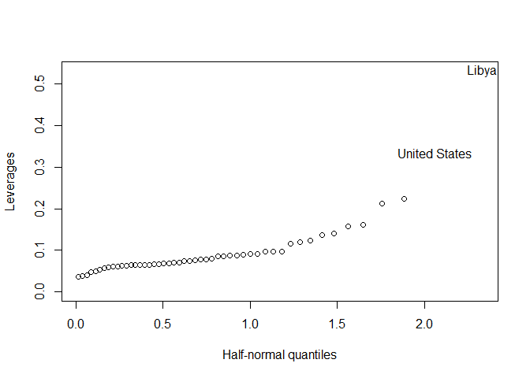

```r
par(mfrow=c(1,1))
countries <- rownames(savings) # stores names of countries
halfnorm(influence(M1)$hat, labs=countries, ylab="Leverages")
```

Plot leverage points against standardized residuals

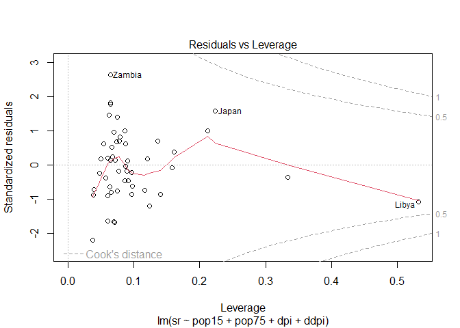

```r
plot(M1, which=5)
```

With the `gglm` package

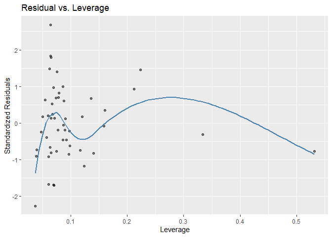

```r
ggplot2::ggplot(data = M1) + stat_resid_leverage()
```

### 1.3.2 Outliers

**Standardized residuals**

```r
M1_sum$sigma
```

```
## [1] 3.802669
```

```r
zresid <- residuals(M1)/(M1_sum$sig) # standardized residuals
head(zresid) # standardized residuals and country names
```

```
##  Australia    Austria    Belgium    Bolivia     Brazil     Canada
##  0.2270983  0.1620930  0.5835265 -0.1836392  0.9342937 -0.0833342
```

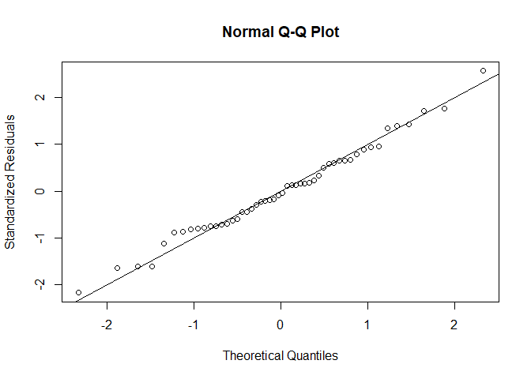

```r
qqnorm(zresid, ylab="Standardized Residuals") # Q-Q plot
abline(0,1) # line 'y = x'
```

**Studentized residuals**

```r
stud <- rstandard(M1) # Studentized residuals and country names
head(stud)
```

```
##   Australia     Austria     Belgium     Bolivia      Brazil      Canada
##  0.23520105  0.17282943  0.61085760 -0.19245030  0.96858807 -0.09083873
```

Definition

```r
head(cbind(residuals(M1)/(M1_sum$sigma*sqrt(1 - M1_inf$hat)), stud))
```

```
##                              stud
## Australia  0.23520105  0.23520105
## Austria    0.17282943  0.17282943
## Belgium    0.61085760  0.61085760
## Bolivia   -0.19245030 -0.19245030
## Brazil     0.96858807  0.96858807
## Canada    -0.09083873 -0.09083873
```

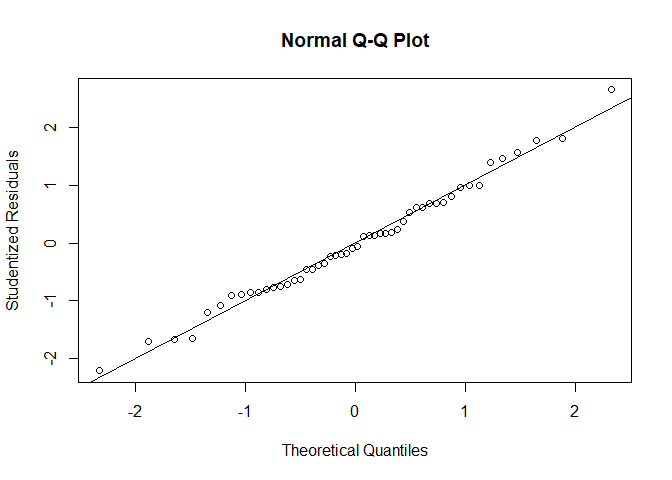

```r
qqnorm(stud, ylab="Studentized Residuals") # Q-Q plot
abline(0,1) # line ’y = x’
```

**Jackknifed Studentized residuals**

```r
jack <- rstudent(M1) # leave-one-out Studentized residuals
```

Definition of leave-one-out Studentized residuals

```r
head(cbind(residuals(M1)/sqrt(M1_inf$sigma^2 * (1-M1_inf$hat)), jack))
```

```
##                              jack
## Australia  0.23271611  0.23271611
## Austria    0.17095506  0.17095506
## Belgium    0.60655220  0.60655220
## Bolivia   -0.19037831 -0.19037831
## Brazil     0.96790816  0.96790816
## Canada    -0.08983197 -0.08983197
```

```r
jack[which.max(abs(jack))]
```

```
##   Zambia
## 2.853558
```

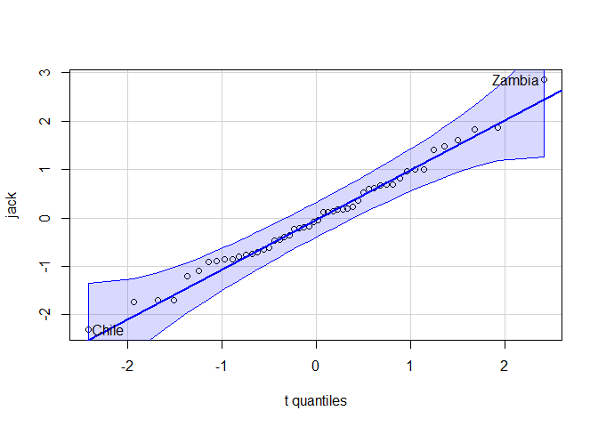

```
## Zambia  Chile
##     46      7
```

```r
library(car)
qqPlot(jack, distribution="t", df=n-k-2)
```

**Is this an outlier?**

$t$ criterium

```r
which(abs(jack) > qt(0.975, n-p-1))
```

```
##  Chile Zambia
##      7     46
```

Dummy criterium

```r
which(abs(jack) > 2)
```

```
##  Chile Zambia
##      7     46
```

Bonferroni criterium

```r
which(abs(jack) > -qt(0.05/(2*n), n-p-1))
```

```
## named integer(0)
```

Bonferroni outlier test

```r
library(car)
outlierTest(M1)
```

```
## No Studentized residuals with Bonferroni p < 0.05
## Largest |rstudent|:
##        rstudent unadjusted p-value Bonferroni p
## Zambia 2.853558          0.0065667      0.32833
```